# act_report

## Report: Insights From WeRateDogs Twitter Archive Data Analysis.

Visualisation of data is an essential part of Analysis. It helps to summarise, interpret and communicate insights drawn from data especially to non technical people. I am going to walk you through analysis I performed on data from [WeRateDogs Archive on twitter](https://twitter.com/weratedogs).  
Python libraries, Matplotlib and Seaborn are going to help communicate my insights

A doggo, which is one of the dog stage from this analysis. image credit: [wired](https://www.wired.com/story/rise-of-doggo/)

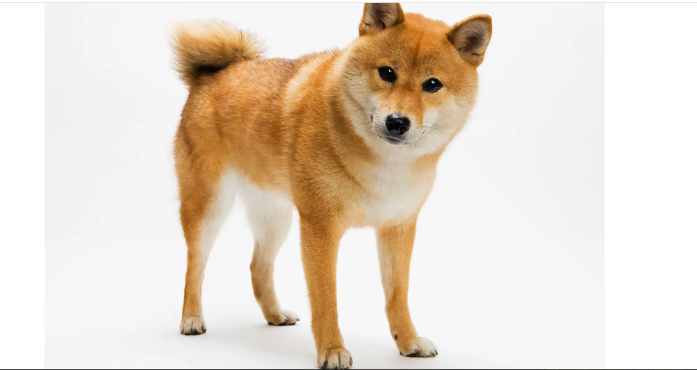

##### Let's begin!

My first two insights were to look for relationships between retweet_count and rating, and favorite_count and rating respectively. Both plots shows no correlation between Features with some outliers in both plots which may be as a result of rating for multiple dogs at once

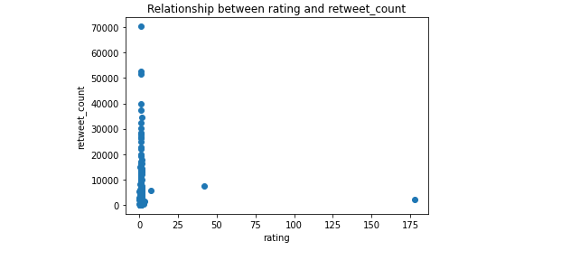

[figure not shown]

The next plot shows relationship between retweet_count and favorite_count.It shows there is a strong, positive and linear relationship with no significant outlier.

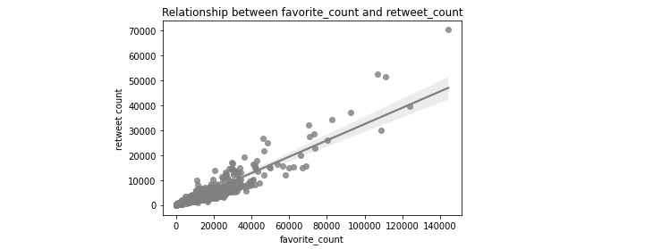

Next visual displays the distribution of data for favorite_count based on each dog_stage also considering multiple stages.Doggo,pupper has the least observations. Puppo has a marginal higher favourite count.The plot also shows possible outliers for each distribution.

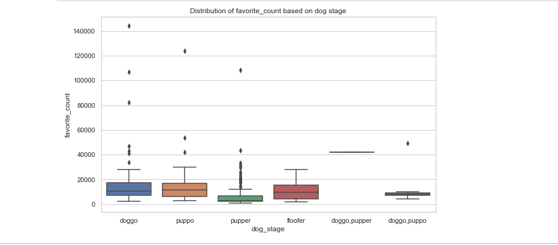

```python
Next insight was to find count of each dog stage. Pupper has the most count.
```

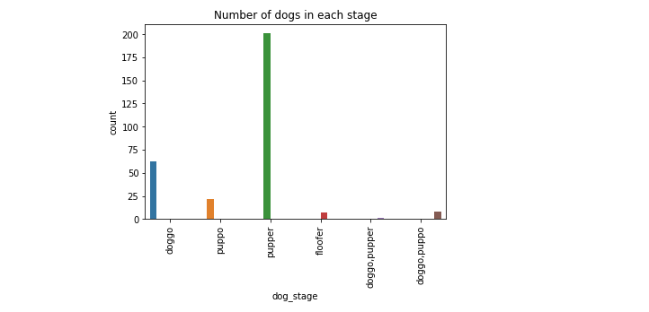

A happy pupper. Photo cedit [CHEEZEburger](https://cheezburger.com/9533612288/one-happy-pupper)

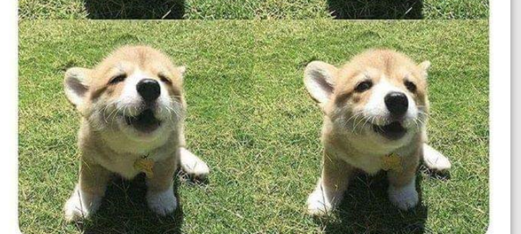

The concluding insight was to find Sources(most used device) of tweets with highest occurence regarding dog stages. Most tweets came from iphones with majority of tweet for pupper.

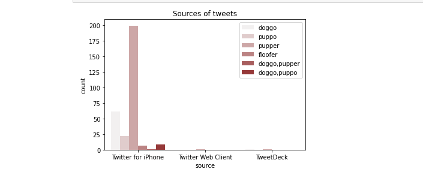

#### Insights drawn from this analysis is based on data I had access to and only covers within a short period of time, and do not give a full representation of the data on the WeRateDogs archive. More data need to be collected and further analysis done to draw unbiased conclusions.